# Velocity-model colour maps: palette sheet (v0.4.2)

Made 2026-11-26 15:51 PST by `workflow/08_figures/model_figures.py palette` (branch paper/model-figures, 7aea31dd). PI request D-B104: colour-blind friendly and beautiful, latest model only. Candidates are Crameri Scientific Colour Maps v8 (Crameri 2018; Crameri, Shephard & Heron 2020), read from GMT's SCM CPTs.

**Convention kept**: slow and low velocity warm, fast cool; high Vp/Vs warm. **Views**: each real panel was drawn once and the whole image (colours, events, lines) was then transformed: deuteranopia, protanopia and tritanopia with the Machado, Oliveira & Fernandes (2009) matrices at severity 1 (complete dichromacy, the worst case), applied in linear RGB; greyscale as the neutral grey of the same CIE luminance. Colour differences are CIEDE2000 (ΔE; about 1 is just noticeable, 10 is an obvious step).

## dVp, dVs (diverging, centred on 0)

Real panel: dVp at 18 km, Washington, events of catalogue cascadia_catalog_v6.0.csv tiers ABC. Rows: candidates; columns: views.

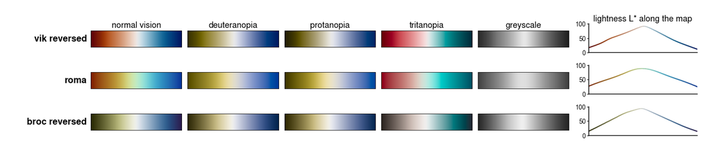

normal vision

deuteranopia

protanopia

tritanopia

greyscale

vik reversed

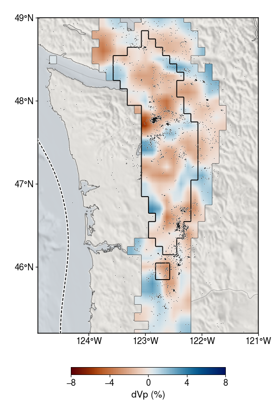

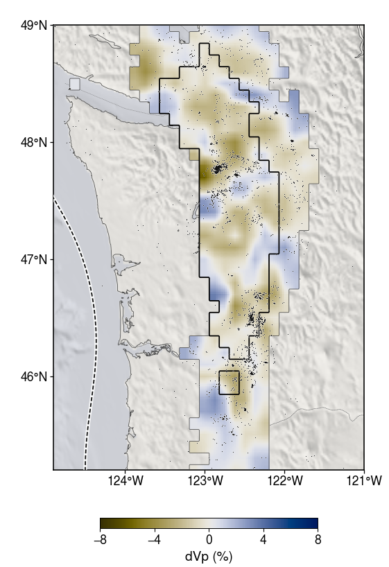

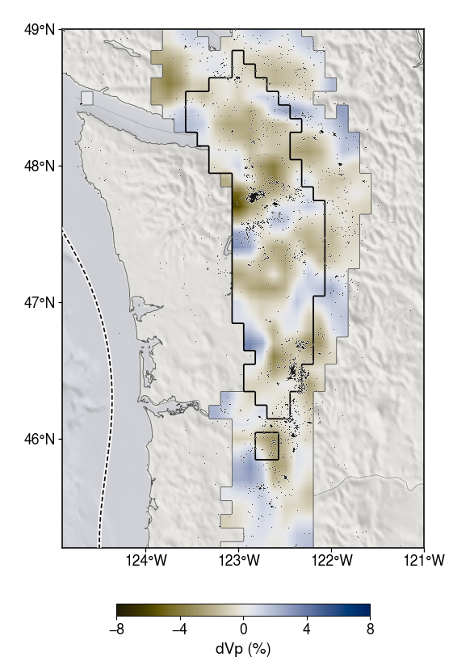

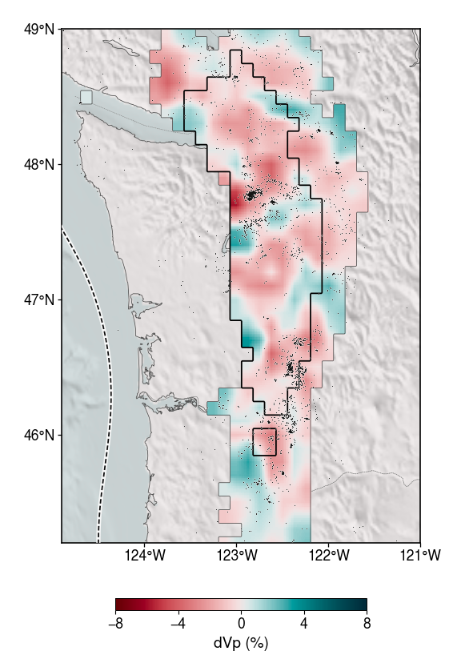

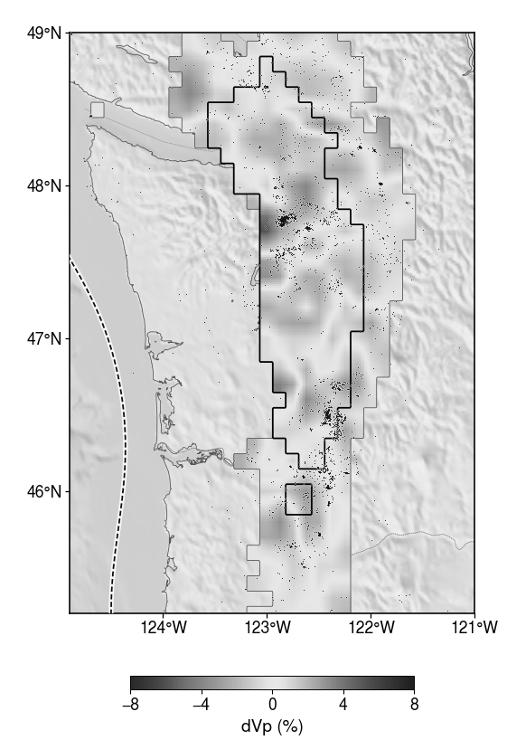

roma

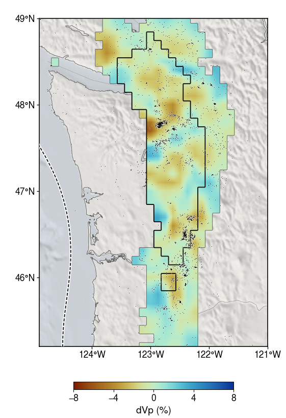

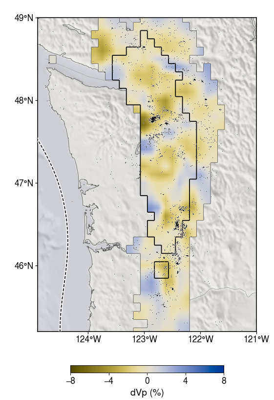

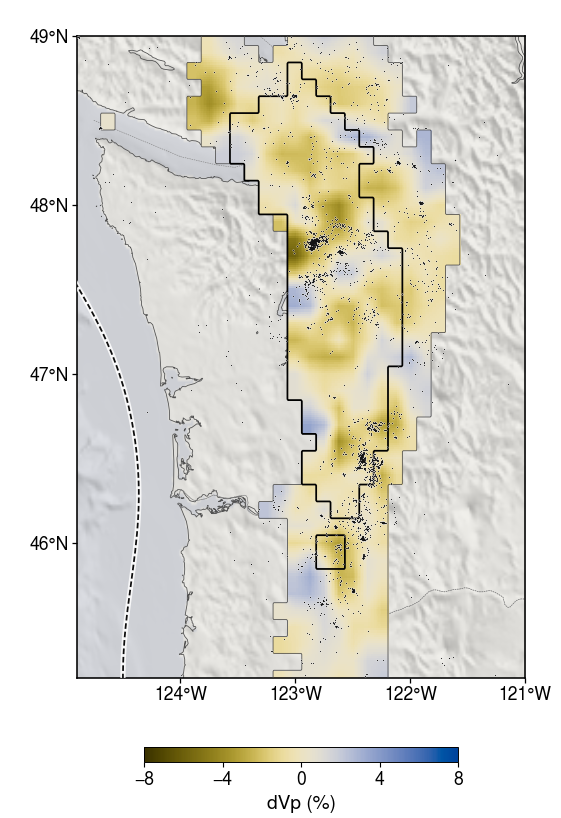

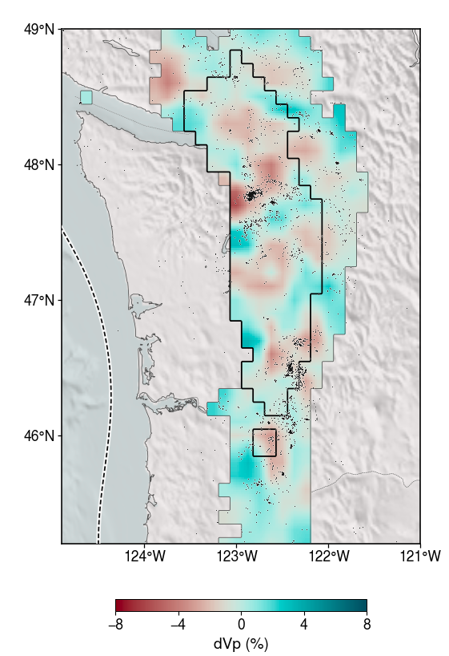

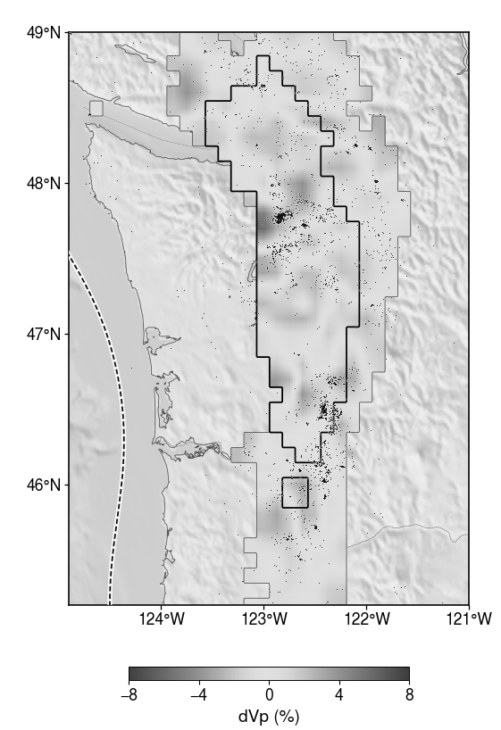

broc reversed

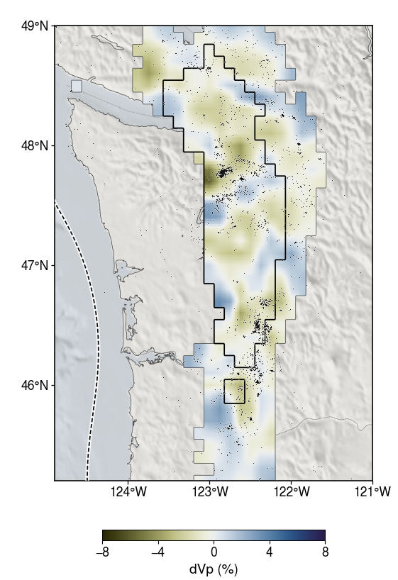

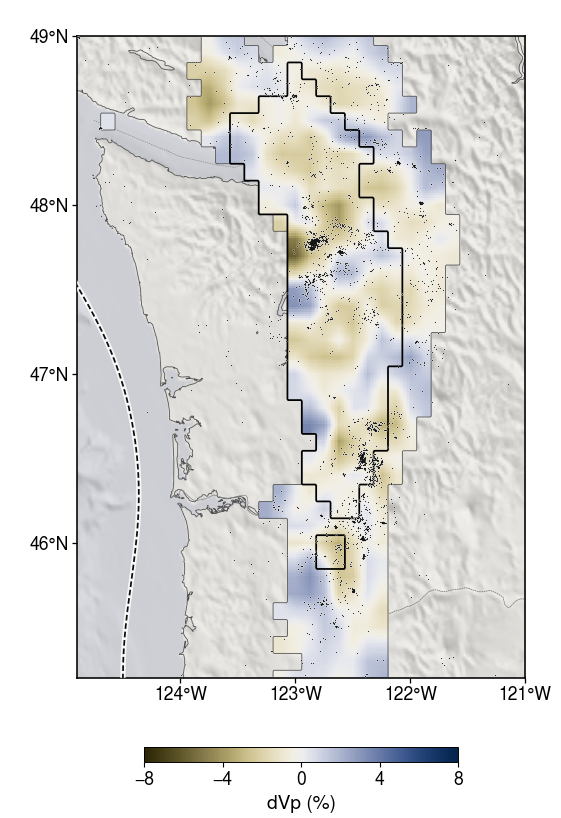

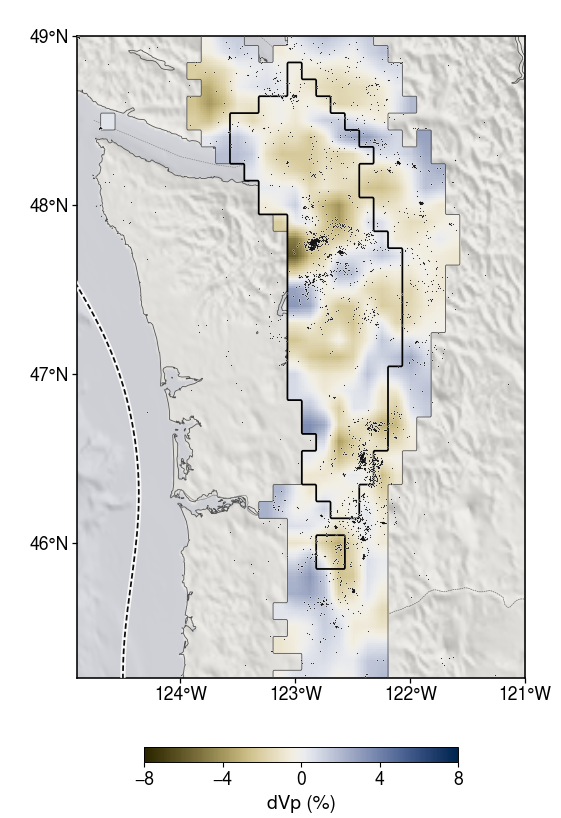

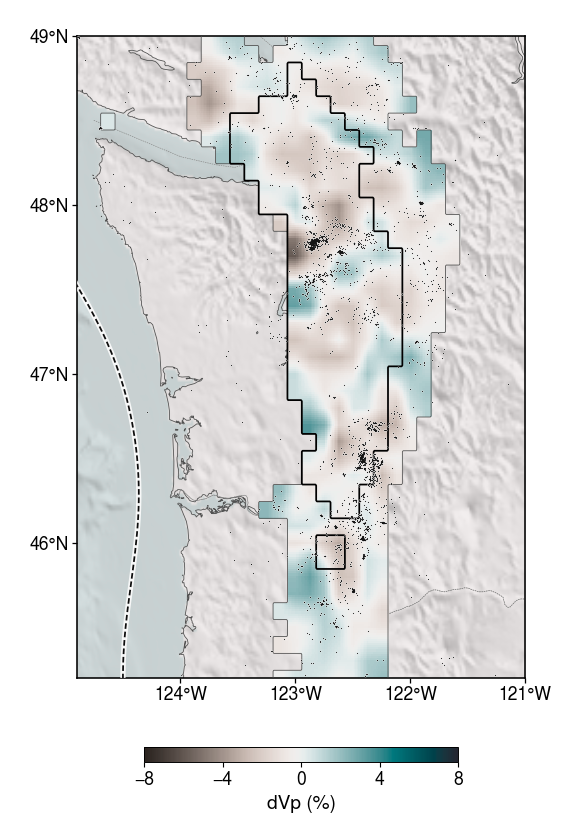

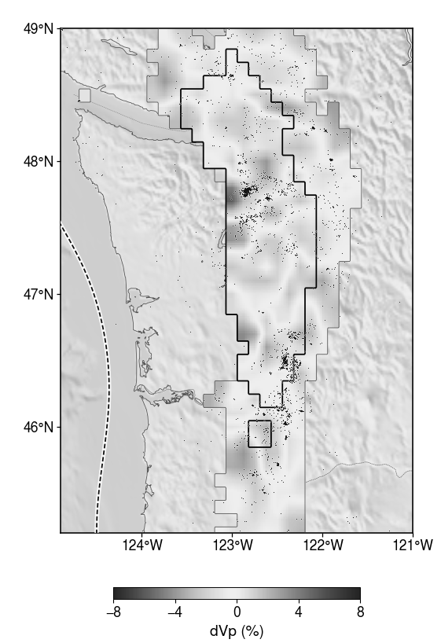

| map | L* low/mid/high | uniformity | length deutan | length protan | length tritan | length grey | weakest 1/8 normal | weakest 1/8 deutan | weakest 1/8 protan | weakest 1/8 tritan | weakest 1/8 grey | arms normal | arms deutan | arms protan | arms tritan | arms grey | dot |
| --- | --- | --- | --- | --- | --- | --- | --- | --- | --- | --- | --- | --- | --- | --- | --- | --- | --- |
| vik reversed | 16 / 91 / 11 | 0.23 | 0.90 | 0.91 | 0.97 | 0.76 | 15.8 | 12.1 | 11.8 | 12.6 | 0.2 | 33.9 | 46.1 | 36.3 | 39.6 | 3.6 | 24.6 |
| roma | 27 / 89 / 25 | 0.19 | 0.84 | 0.88 | 0.90 | 0.66 | 17.5 | 13.0 | 13.5 | 11.5 | 0.2 | 42.6 | 48.0 | 45.2 | 45.8 | 0.2 | 28.9 |
| broc reversed | 14 / 94 / 14 | 0.20 | 0.93 | 0.93 | 0.99 | 0.80 | 13.7 | 11.3 | 13.2 | 9.6 | 0.1 | 40.5 | 34.6 | 35.5 | 9.6 | 0.6 | 15.7 |

## Vp, Vs (sequential)

Real panel: Vp at 29 km, Mendocino (range of Fig. M1), events of catalogue cascadia_catalog_v6.0.csv tiers ABC. Rows: candidates; columns: views.

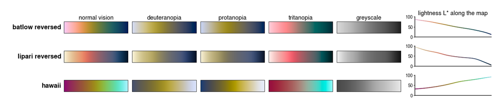

normal vision

deuteranopia

protanopia

tritanopia

greyscale

batlow reversed

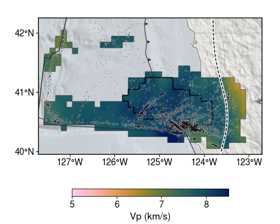

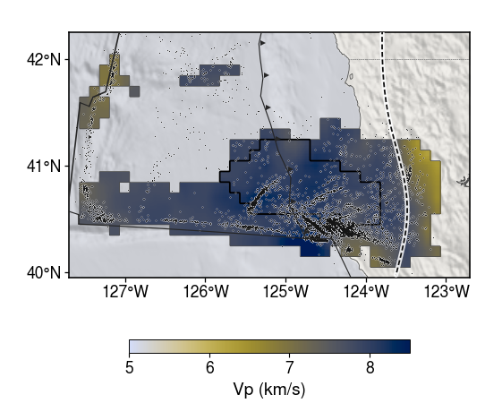

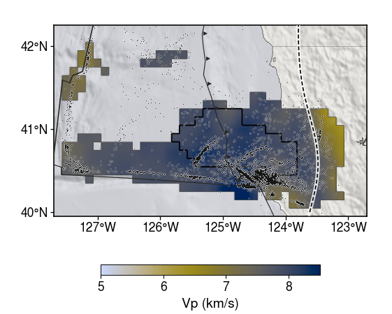

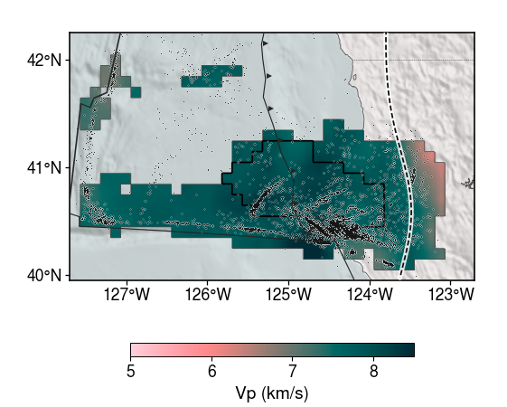

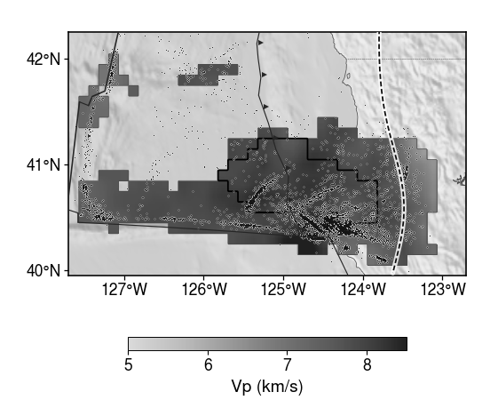

lipari reversed

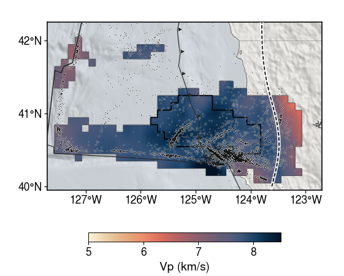

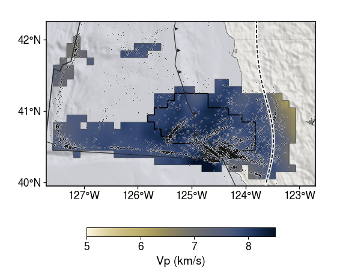

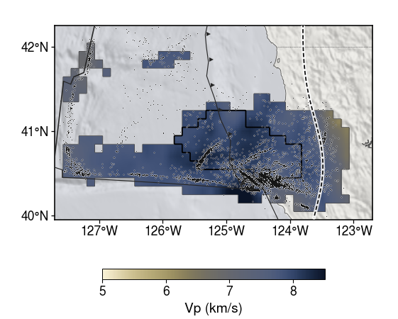

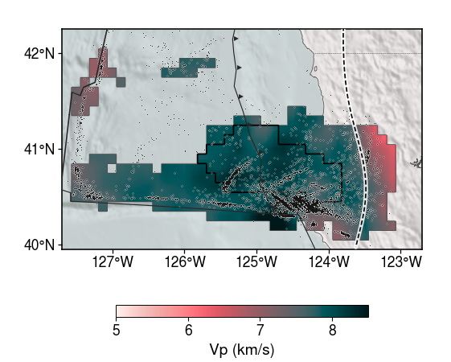

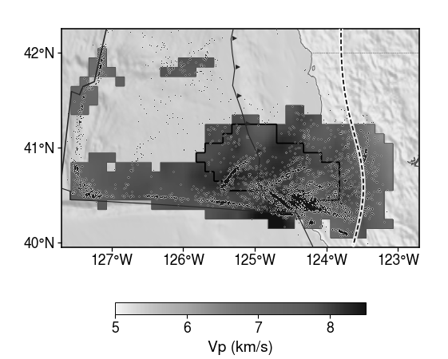

hawaii

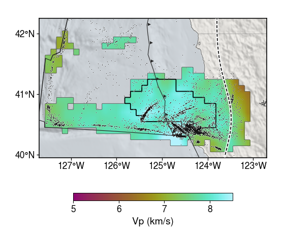

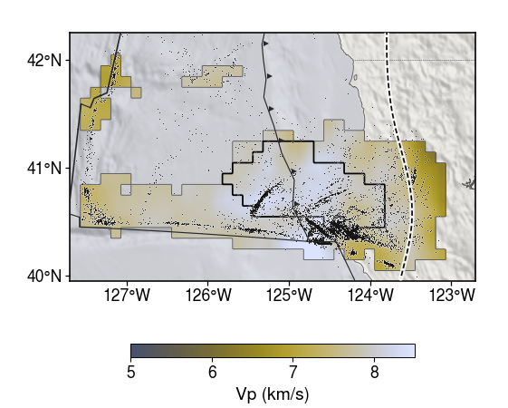

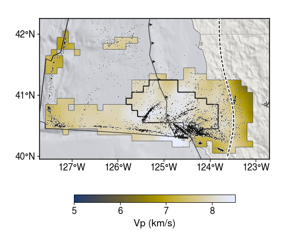

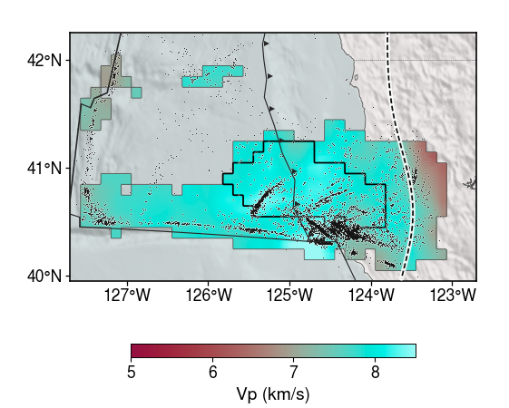

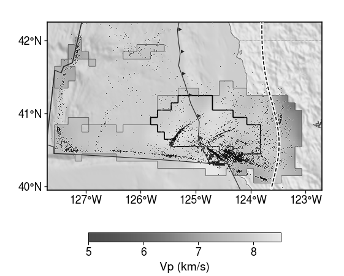

| map | L* low/mid/high | uniformity | length deutan | length protan | length tritan | length grey | weakest 1/8 normal | weakest 1/8 deutan | weakest 1/8 protan | weakest 1/8 tritan | weakest 1/8 grey | dot |
| --- | --- | --- | --- | --- | --- | --- | --- | --- | --- | --- | --- | --- |
| batlow reversed | 87 / 53 / 12 | 0.28 | 0.80 | 0.79 | 0.73 | 0.40 | 14.7 | 8.4 | 6.5 | 6.2 | 4.5 | 19.7 |
| lipari reversed | 97 / 49 / 6 | 0.34 | 0.77 | 0.75 | 0.97 | 0.53 | 12.6 | 6.3 | 5.9 | 10.3 | 3.5 | 11.1 |
| hawaii | 31 / 61 / 92 | 0.33 | 0.78 | 0.88 | 0.74 | 0.37 | 11.3 | 7.2 | 8.8 | 4.7 | 3.0 | 31.3 |

## Vp/Vs (diverging, centred on 1.75)

Real panel: Vp/Vs section B, Mendocino 40.4°N (Fig. M2), events of catalogue cascadia_catalog_v6.0.csv tiers ABC. Rows: candidates; columns: views.

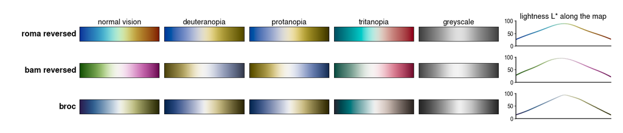

normal vision

deuteranopia

protanopia

tritanopia

greyscale

roma reversed

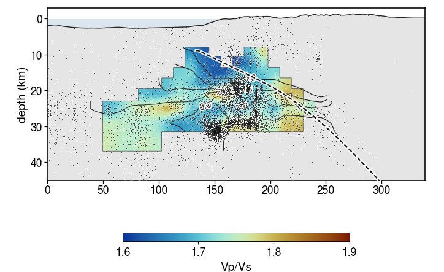

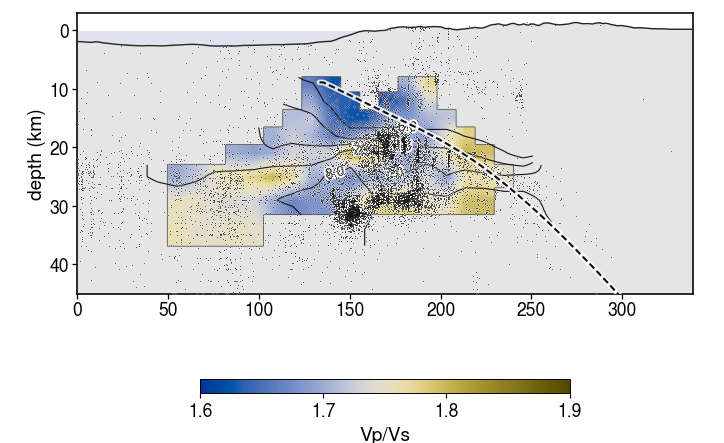

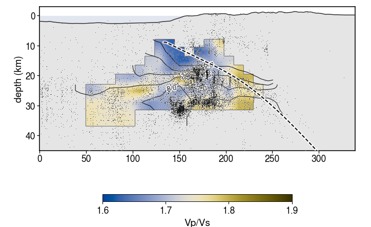

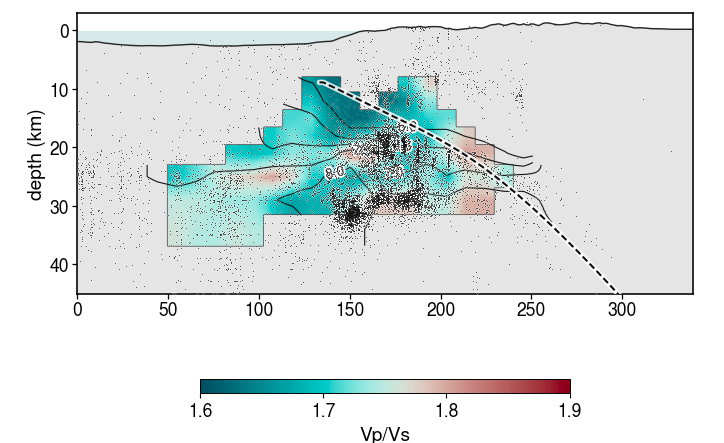

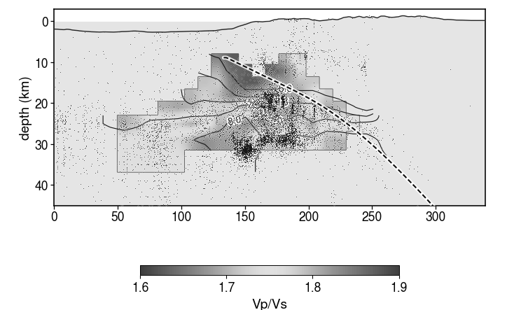

bam reversed

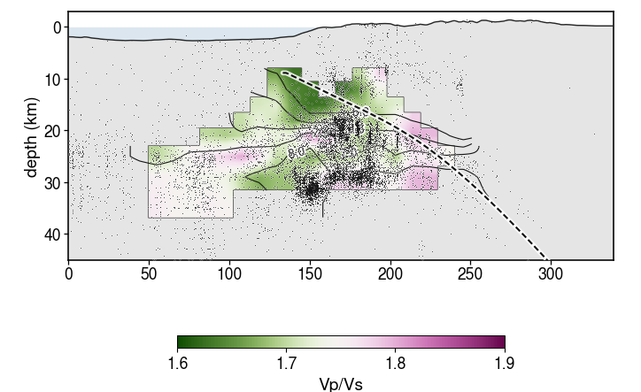

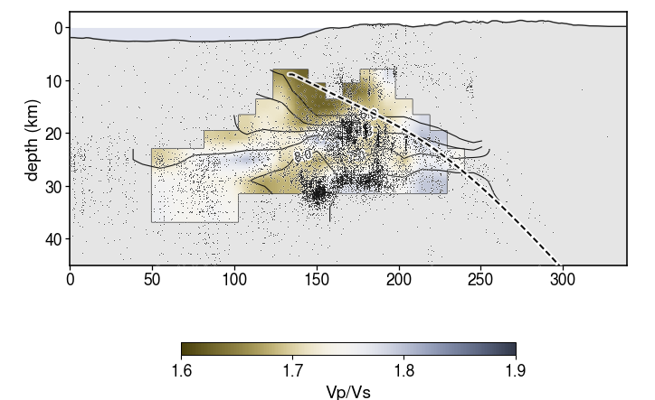

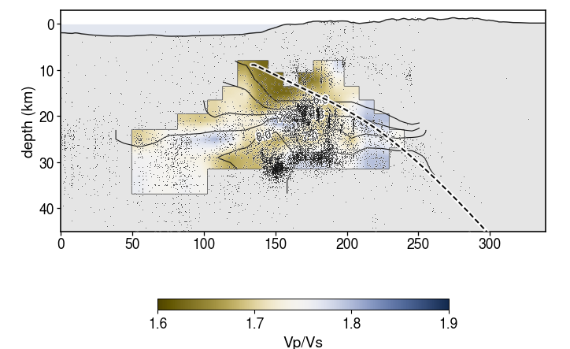

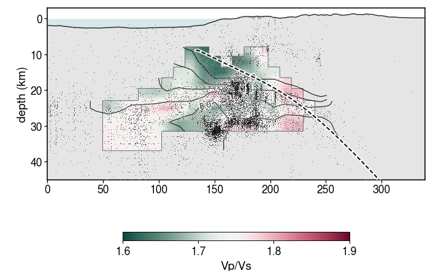

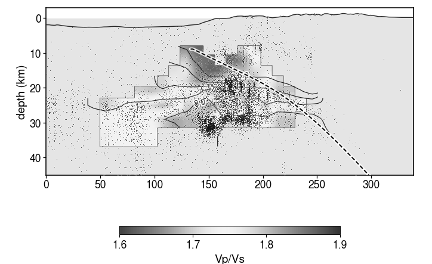

broc

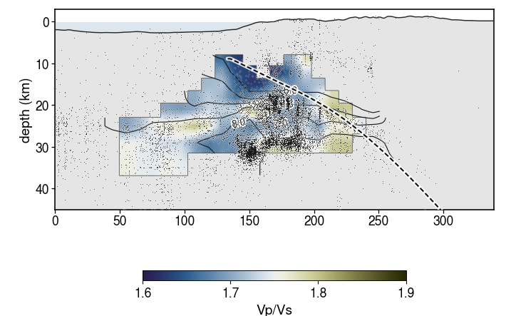

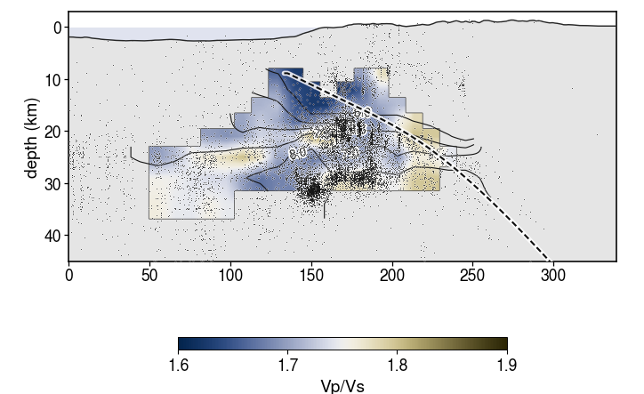

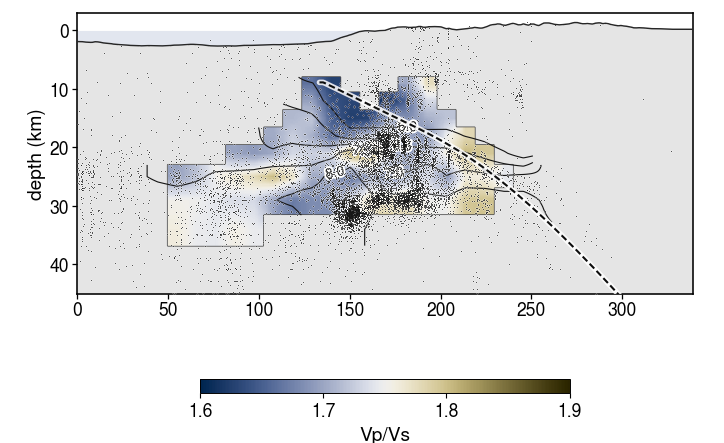

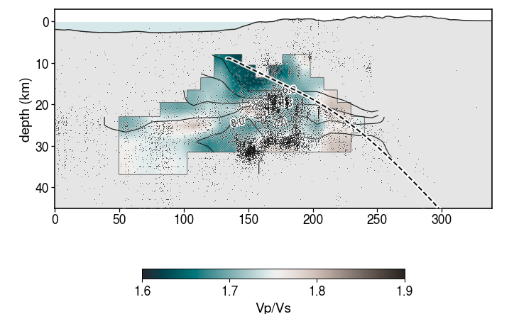

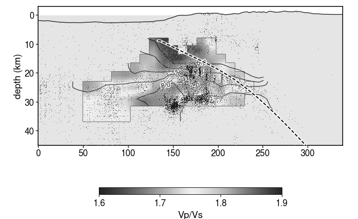

| map | L* low/mid/high | uniformity | length deutan | length protan | length tritan | length grey | weakest 1/8 normal | weakest 1/8 deutan | weakest 1/8 protan | weakest 1/8 tritan | weakest 1/8 grey | arms normal | arms deutan | arms protan | arms tritan | arms grey | dot |
| --- | --- | --- | --- | --- | --- | --- | --- | --- | --- | --- | --- | --- | --- | --- | --- | --- | --- |
| roma reversed | 25 / 89 / 27 | 0.19 | 0.84 | 0.88 | 0.90 | 0.66 | 17.5 | 13.0 | 13.5 | 11.5 | 0.2 | 42.4 | 47.9 | 45.2 | 46.0 | 0.0 | 28.9 |
| bam reversed | 27 / 96 / 21 | 0.23 | 0.88 | 0.92 | 0.93 | 0.75 | 16.6 | 8.7 | 11.1 | 9.8 | 0.0 | 61.5 | 29.5 | 40.9 | 42.2 | 4.8 | 26.4 |
| broc | 14 / 94 / 14 | 0.20 | 0.93 | 0.93 | 0.99 | 0.80 | 13.7 | 11.3 | 13.2 | 9.6 | 0.1 | 40.2 | 34.8 | 35.1 | 10.0 | 0.0 | 15.7 |